# Estudio variabilidad estructural proteica

30/01/2016

## Conjuntos de proteinas

### Conjunto teorico

170 mutantes de 1pob (118 sitios) simuladas con el modelo mutacional LFENM con ANM *R0* = 12 y *Fmax* = 2 (solo para LFENM). Para determinar que sitios mutar, se alineo 1pob con cada una de las proteinas del conjunto, se obtuvieron los indices de los sitios alineados pero mutados y se simularon 10 mutantes por cada par de proteinas, obteniendose un total de 170 mutantes. Luego, para el analisis, se tomaron como alineados los sitios alineados de 1pob para cada par de proteinas.

### Conjunto experimental

17 proteinas de la familia de phoslip. Las proteinas tienen un promedio de identidad secuencial de 43%. El core del alineamiento de la familia es de 111 sitios.

La caracterizacion del conjunto experimental se muestra a continuacion:

```
##    pdbid nsites naligned identity      MSD
## 1   1bp2    123      117 57.26496 1.050660
## 2   1p2p    124      118 54.23729 2.054263
## 3   1ae7    119      117 53.84615 3.011483
## 4  1buna    120      116 51.72414 2.535954
## 5   1vip    121      112 42.85714 1.686987
## 6   1vpi    122      111 40.54054 2.479303
## 7  1aokb    122      112 43.75000 2.103974
## 8   1psj    124      112 41.96429 2.669422
## 9  1vapa    123      112 42.85714 2.057442
## 10 1pp2r    122      112 40.17857 2.560502
## 11 1jiaa    122      112 41.96429 1.978162
## 12 1a2aa    122      112 41.96429 1.410738
## 13 1cl5a    121      112 38.39286 2.190447
## 14 1clpa    121      112 35.71429 2.661561
## 15 1goda    121      112 36.60714 1.795260
## 16  1ppa    121      112 32.14286 2.380420
## 17  1bbc    124      112 39.28571 2.033943
```

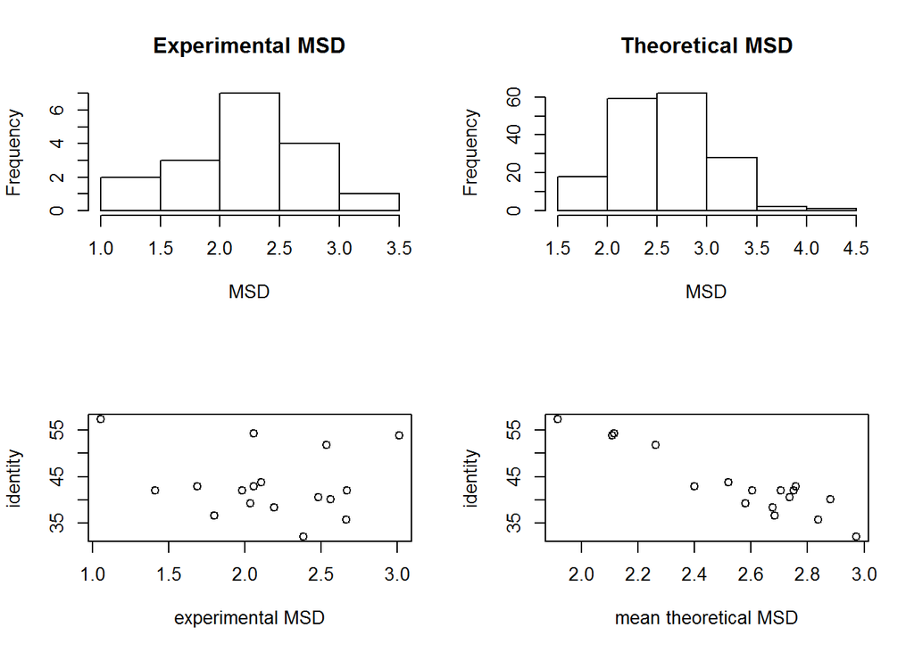

## Comparaciones

### RHO y AUC

Las distribuciones de *auc* y *rho* para cada conjunto se muestran a continuacion (azul= teorico, rojo = experimental)

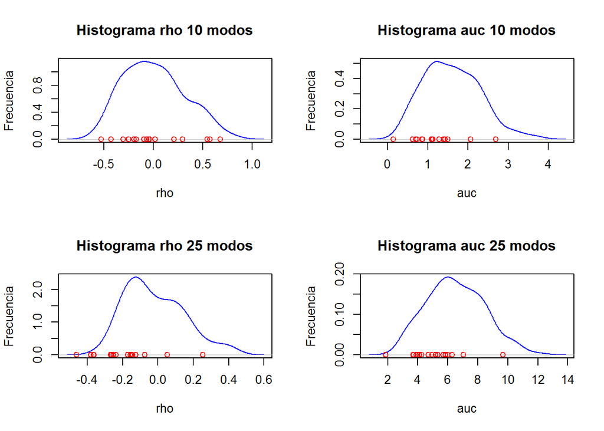

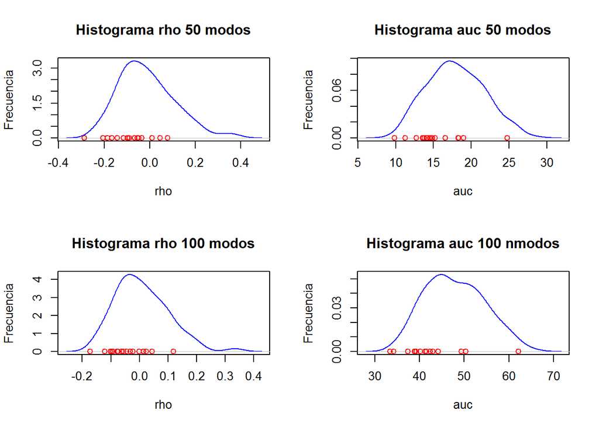

## Pn y Qn

Las distribuciones de *Pn* y *Qn* de los conjuntos son las siguientes:

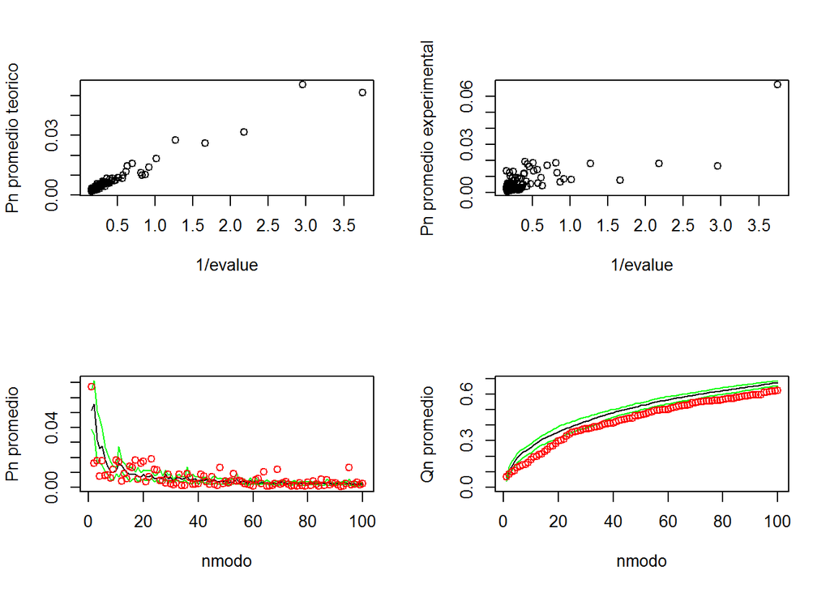

Negro: Teorico Rojo: Experimental Verdes: Cuartiles 0.05 y 0.95 de 10 grupos de 17 mutantes teoricas.